## Curso de R no IPÊ

### Script do dia 4.1: Matrizes e Cluster

*Marcos V. C. Vital e participantes da turma de 2014*

Para mais material, acesse http://marcosvital.wordpress.com/

Este documento é a 1a parte do quarto de uma série que nasceu durante as atividades do “Curso de introdução ao uso do software R e suas aplicações estatísticas nas ciências biológicas”, realizado no IPÊ em dezembro de 2014.

Nesta parte do guia nós vamos criar matrizes de distância e representá-las em dendogramas hierárquicos.

Como sempre, todo o documento foi criado utilizando o software R, o programa RStudio e a linguagem Markdown. Para saber mais, acesse:

http://www.r-project.org/

http://www.rstudio.com

http://rmarkdown.rstudio.com/

**Antes de começar, carregue os dados necessários:**

```r
setwd("C:/R/Curso IPÊ")
dados<-read.table("insetos.txt", h=T, row.names=1)
attach(dados)

#Aqui um summary vai ser muito carregado, então vou usar um str:
str(dados)
```

```
## 'data.frame':    30 obs. of  40 variables:
##  $ Ambiente   : Factor w/ 2 levels "Mata_Primária",..: 1 1 1 1 1 1 1 1 1 1 ...
##  $ Gado       : Factor w/ 2 levels "Ausente","Presente": 2 1 2 2 2 1 1 1 2 2 ...
##  $ Temperatura: num  21.8 21.3 23.8 23.2 21.5 21.7 20.3 19.7 24.7 20.2 ...
##  $ Cobertura  : int  73 62 57 49 59 78 64 74 48 75 ...
##  $ Luz        : num  53.5 61 71.5 69.5 61.5 53 58 56 71 60.5 ...
##  $ Flores     : int  14 28 17 29 15 24 21 29 20 5 ...
##  $ sp.1       : int  4 5 1 3 5 1 1 0 6 3 ...
##  $ sp.2       : int  0 0 0 0 0 0 3 1 4 0 ...
##  $ sp.3       : int  7 3 2 6 7 2 2 1 8 3 ...
##  $ sp.4       : int  2 7 0 4 2 4 5 3 3 1 ...
##  $ sp.5       : int  0 2 2 1 1 0 3 4 0 0 ...
##  $ sp.6       : int  0 5 2 14 4 3 3 9 8 0 ...
##  $ sp.7       : int  3 2 3 2 1 4 3 2 1 3 ...
##  $ sp.8       : int  2 4 3 5 2 3 0 0 1 0 ...
```

[output cut: 26 more lines]

Notou uma coisa diferente?

Nós usamos o argumento `row.names` para informar o R os nomes das linhas!

#### Passo a passo para criar um cluster:

**Etapa 0: se necessário, padronize os seus dados**

```r
dados.amb<-dados[,3:6] #Separei os dados de interesse
dados.amb.pad<-scale(dados.amb) #Padronizei os dados
```

A novidade aqui é a função `scale` que padroniza os dados (subtrai da média e divide pelo desvio padrão).

**Etapa 1: crie sua matriz de distância**

```r
amb.dist<-dist(dados.amb.pad, method="euclid")
```

Aqui usamos a função `dist`, e escolhemos a distância euclidiana com o argumento `method`

**Etapa 2: crie o seu cluster**

```r
amb.cluster<-hclust(amb.dist, method="average")
```

Usamos a função `hclust`, e definimos o método de UPGMA pelo argumento `method`

**Etapa 3: calcule o coeficiente de correlação cofenética**

```r
matriz.cof<-cophenetic(amb.cluster)  #Cria a matriz coefenética
cor(amb.dist, matriz.cof)               #Calcula o coeficiente
```

```
## [1] 0.7388642
```

Aqui usamos a função `cophenetic` para extrair a matriz cofenética, e a função `cor` para calcular a correlação de pearson.

O coeficiente apresentou um valor adequado, então vamos lá plotar o nosso cluster!

#### Plotando o nosso cluster

Existem diversas maneiras de se plotar um cluster no R. Vamos explorar apenas algumas, ok?

**Rápidão!**

O mais rápido e simples é:

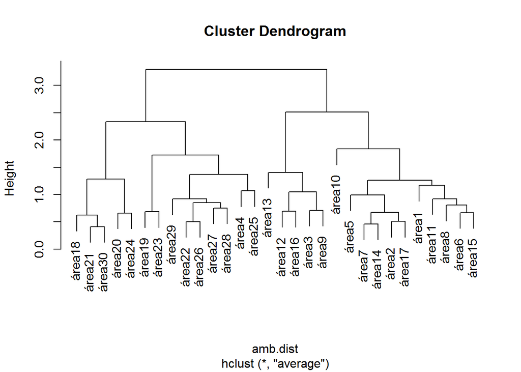

```r
plot(amb.cluster)
```

Não é la muito bonito, mas quebra galho para uma visualização rápida.

Você pode usar o argumento `hang` para que ele estique os ramos e deixe os nomes lado a lado, assim:

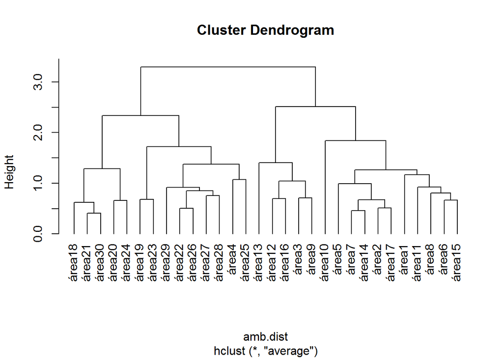

```r
plot(amb.cluster, hang=-1)
```

**De lado**

Você pode colocar o cluster na horizontal convertendo ele em outra categoria de objeto. São duas alternativas: você pode usar a função `as.phylo` do pacote `ape`; ou pode usar a `as.dendrogram`.

Usando a primeira:

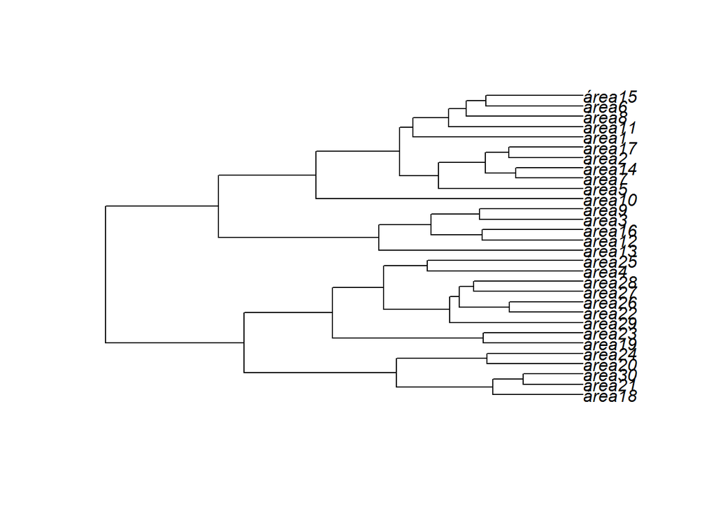

```r
library(ape)

plot(as.phylo(amb.cluster))
```

E a segunda (neste caso precisamos do argumento `horiz` para deixá-lo na horizontal:

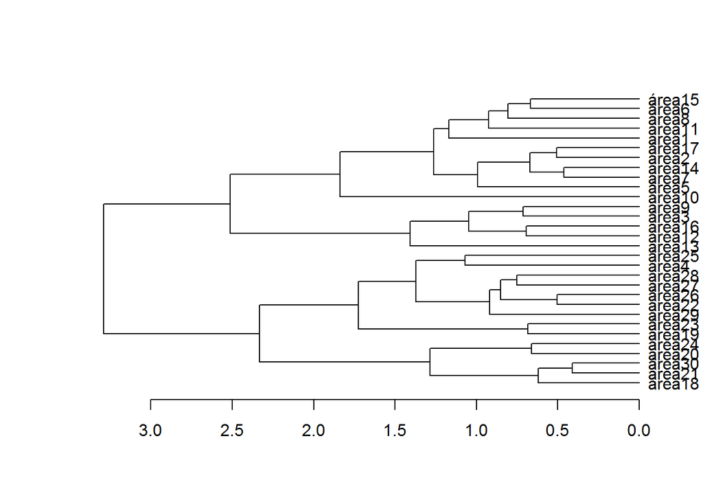

```r
plot(as.dendrogram(amb.cluster), horiz=T) #horiz=T faz na horizontal
```

Mas nos dois casos uma coisa não ficou legal: os nomes ficaram espremidos…

Isto pode ser resolvido de uma maneira simples: aumentando o tamanho da janela do gráfico. Vamos lá:

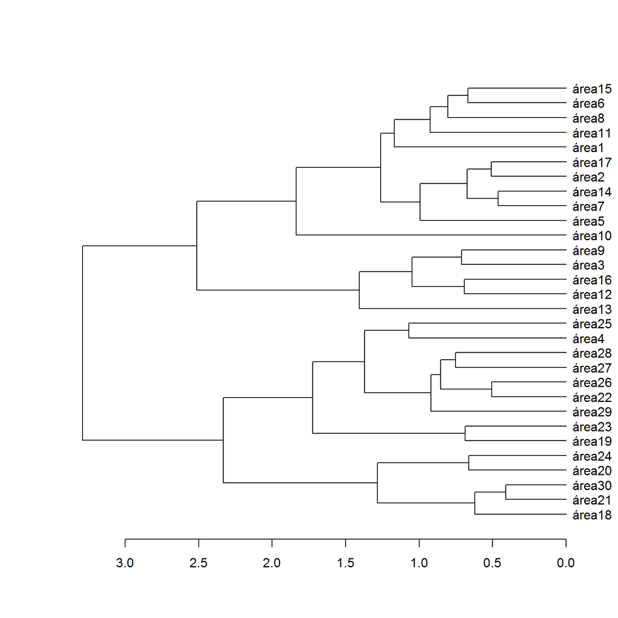

```r
windows(width=8, height=8, rescale="fixed")
plot(as.dendrogram(amb.cluster), horiz=T)
```

Aqui temos novidades:

- a função `windows` abre uma janela para gráfico com o tamanho que determinarmos;
- os argumentos `width` e `heigh`determinam a largura e altura da janela, respectivamente;
- o argumento `rescale="fixed"` faz com que a figura não mude de tamanho quando mexemos na janela;

**Alterando nomes**

Uma das coisas legais do R é que podemos mexer aqui e ali e encontrar maneiras de solucionar problemas, representar coisas e tudo mais sem ter que voltar atrás, mexer nos dados originais e coisas do tipo.

Imagine, por exemplo, que você queira alterar os nomes das unidades amostrais para identificá-las como sendo pertencentes aos dois tipos de mata descritos na variável ambiente. Como fazer isso sem sair do R?

Vamos lá:

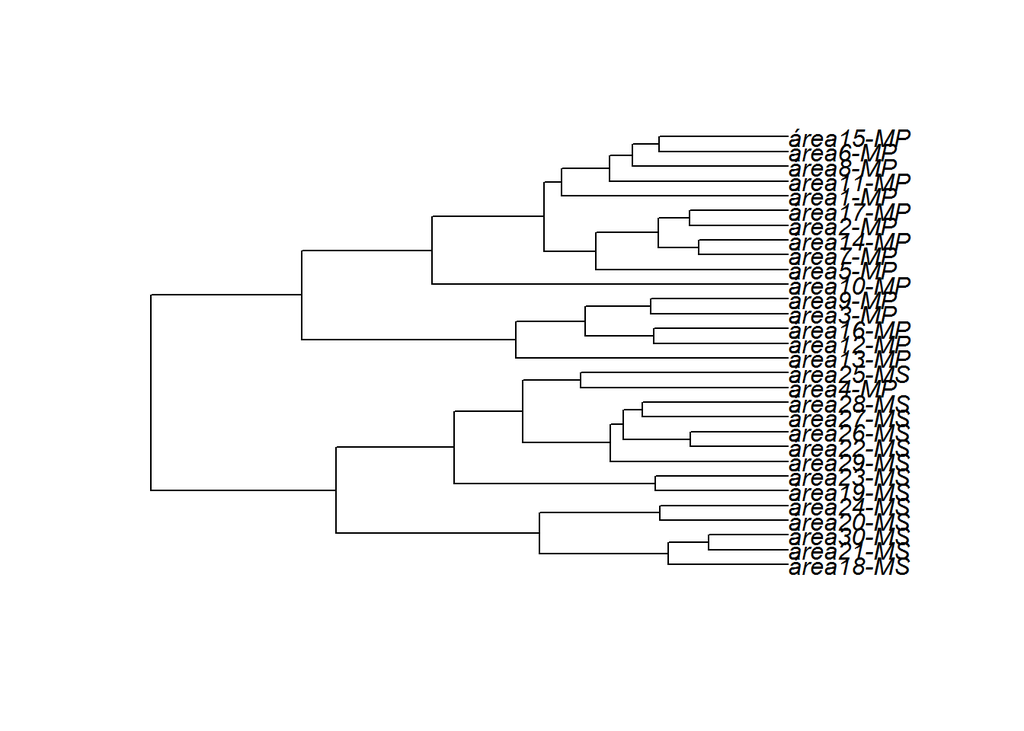

```r
códigos<-ifelse(dados$Ambiente=="Mata_Primária", "MP", "MS")
novos.nomes<-paste(row.names(dados), códigos, sep="-")
amb.cluster$labels<-novos.nomes

plot(as.phylo(amb.cluster))
```

O que fizemos aqui?

- `ifelse` você já conhece, e foi usada para criar códigos para serem acrescentados aos nomes;
- `paste` permite que eu junte nomes, expressões e coisas assim, e foi usada para criarmos os nomes novos;
- `$labels` foi usado para acessarmos os nomes usados no cluster.

Bacana, né?

**Mas peraí, como você sabia desse esquema do $labels?**

Existe uma função bem básica mas extremamente útil no R, chamada `ls`.

Esta função serve, inicialmente, para listarmos os objetos na memória do R. Por exemplo:

```r
ls()
```

```
## [1] "amb.cluster"   "amb.dist"      "códigos"       "dados"
## [5] "dados.amb"     "dados.amb.pad" "matriz.cof"    "novos.nomes"
```

Mas ela também pode ser usada para listarmos o que está dentro de um objeto, o que pode nos ajudar a entender os seus componentes. No caso do cluster, eu soube que os nomes deveriam estar ali, por olhei para o resultado do `ls`, assim:

```r
ls(amb.cluster)
```

```
## [1] "call"        "dist.method" "height"      "labels"      "merge"
## [6] "method"      "order"
```

#### Criando um mapa de calor

*Este pedacinho só vai funcionar se você tiber o arquivo ‘Coldiss.R’ que acompanha o livro Numerical Ecology with R.*

Um mapa de calor é uma representação visual da matriz de distância, na qual os números são substituídos por cores em uma escala. O resultado pode ser bastante intuitivo:

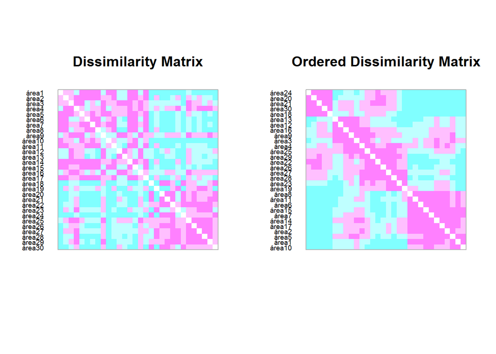

```r
source("Coldiss.R")

coldiss(amb.dist)
```

Aqui nós usamos a função `source` para acessar o arquivo e criar a função `coldiss`

#### Escolhendo outras métricas de distância

Ao fazer o nosso cluster la em cima, trabalhamos com a distância euclidiana. Mas, como vimos, outras métricas podem ser necessárias, dependendo de coisas como a natureza dos meus dados e as minhas perguntas.

Vamos, então, olhar rapidamente para alguns exemplos bem simples, ok? Você irá precisar do pacote `vegan`.

**Coeficiente de Bray-Curtis:**

```r
library(vegan)
```

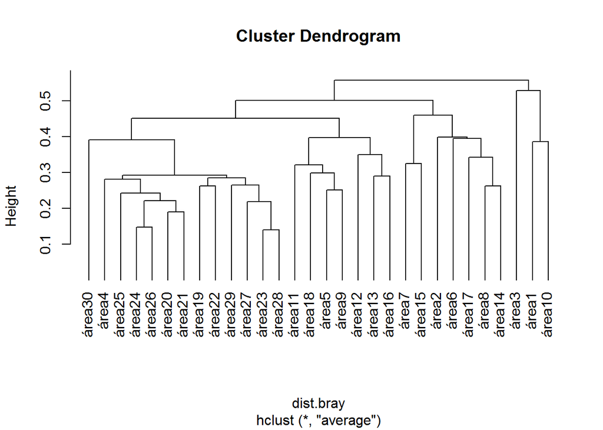

```r
dist.bray<-vegdist(dados[,7:40], method="bray")
cluster.bray<-hclust(dist.bray, method="average")
plot(cluster.bray, hang=-1)
```

Aqui usamos a função `vegdist`, que tem um monte de métricas acessíveis pelo argumento `method`;

**Coeficiente de Jaccard:**

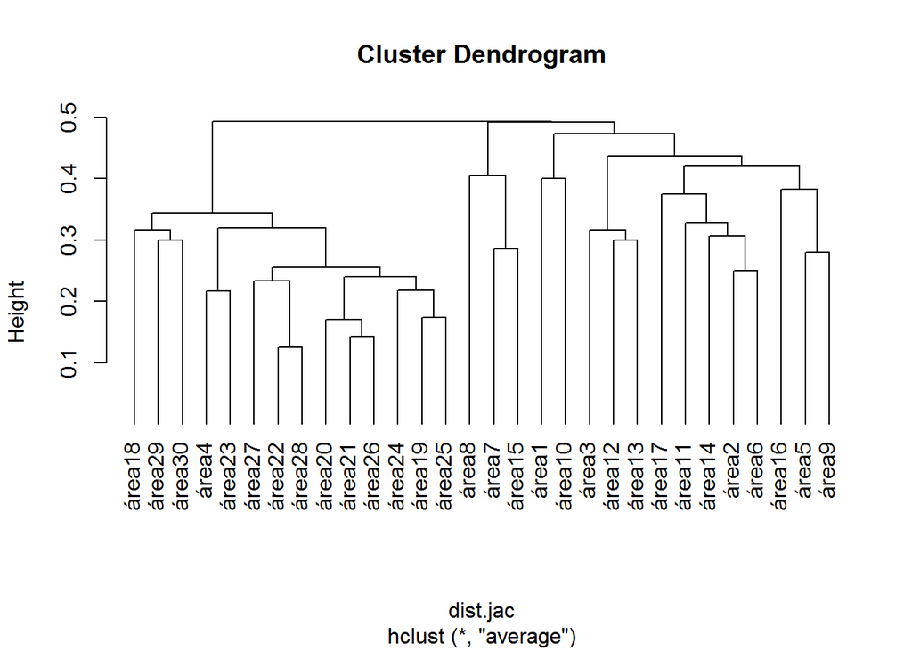

```r
dist.jac<-vegdist(dados[,7:40], method="jac", binary=T)
cluster.jac<-hclust(dist.jac, method="average")
plot(cluster.jac, hang=-1)
```

Aqui adicionamos o argumento `binary` para indicar que queremos usar apenas a presença e ausência das espécies.

**Outras métricas?**

O pacote `vegan` possui uma função bem bacana, que permite criar uma métrica desejada. Vale à pena dar uma espiada nela:

```
?designdist
```

**Ufa, terminamos mais um. Ainda temos mais coisas do mesmo dia, então vamos continuar!**